# Housing Case Study

## Imports

```python
import pandas as pd
import numpy as np
import matplotlib.pyplot as plt
import seaborn as sns
```

```python
# Load the data from CSV or Parquet files
home_values = pd.read_parquet("hf://datasets/misikoff/zillow-viewer/home_values.parquet")
rentals = pd.read_parquet("hf://datasets/misikoff/zillow-viewer/rentals.parquet")
```

```python
home_values.head()
```

|  | Region ID | Size Rank | Region | Region Type | State | Home Type | Bedroom Count | Date | Bottom Tier ZHVI (Smoothed) (Seasonally Adjusted) | Mid Tier ZHVI (Smoothed) (Seasonally Adjusted) | Top Tier ZHVI (Smoothed) (Seasonally Adjusted) |
| --- | --- | --- | --- | --- | --- | --- | --- | --- | --- | --- | --- |
| 0 | 3 | 48 | Alaska | 4 | Alaska | 3 | 0 | 2000-01-31 | NaN | 81310.640625 | NaN |
| 1 | 3 | 48 | Alaska | 4 | Alaska | 3 | 0 | 2000-02-29 | NaN | 80419.765625 | NaN |
| 2 | 3 | 48 | Alaska | 4 | Alaska | 3 | 0 | 2000-03-31 | NaN | 80480.453125 | NaN |
| 3 | 3 | 48 | Alaska | 4 | Alaska | 3 | 0 | 2000-04-30 | NaN | 79799.203125 | NaN |
| 4 | 3 | 48 | Alaska | 4 | Alaska | 3 | 0 | 2000-05-31 | NaN | 79666.468750 | NaN |

```python
rentals.head()
```

|  | Region ID | Size Rank | Region | Region Type | State | Home Type | Date | Rent (Smoothed) | Rent (Smoothed) (Seasonally Adjusted) |
| --- | --- | --- | --- | --- | --- | --- | --- | --- | --- |
| 0 | 66 | 146 | Ada County | 2 | Ada County | 4 | 2015-01-31 | 927.493774 | 927.493774 |
| 1 | 66 | 146 | Ada County | 2 | Ada County | 4 | 2015-02-28 | 931.690613 | 931.690613 |
| 2 | 66 | 146 | Ada County | 2 | Ada County | 4 | 2015-03-31 | 932.568604 | 932.568604 |
| 3 | 66 | 146 | Ada County | 2 | Ada County | 4 | 2015-04-30 | 933.148132 | 933.148132 |
| 4 | 66 | 146 | Ada County | 2 | Ada County | 4 | 2015-05-31 | 941.045715 | 941.045715 |

## ER Diagram & UML Diagram -- Home Values

To conceptually organize the dataset, clarifying relationships, attributes, and dependencies, making it easier to structure your analysis later, I have constructed the following diagrams based on the home_values dataset.

### Entity-Relationship Diagram

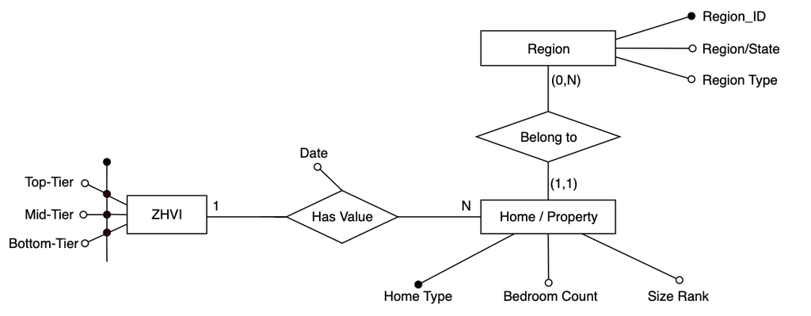

**Assumptions Made:**

- Each home belongs to one region (can’t belong to multiple regions)
- Each ZHVI balue is associated with a home and a Date
- Each home has three ZHVI values (for the three tiers).

### UML Diagram

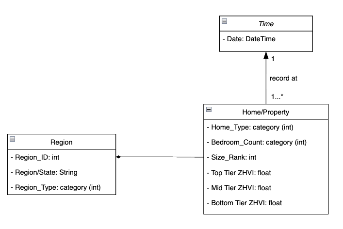

**Assumptions Made:**

- Home/Property belongs to a region
  - Every home belongs to exactly one region, and a region can have multiple homes
- Composite association between region and home
  - A home will ALWAYS be associated with one location (region)
  - A home cannot exist independently of a Region.

## Exploratory Data Analysis (EDA) / Data Preprocessing

Now to take a deeper look at the data itself, we want to first make sure the data is clean and have no missing values.

```python
# Check if there is any missing values
home_values.isnull().sum()
```

|  | 0 |
| --- | --- |
| Region ID | 0 |
| Size Rank | 0 |
| Region | 0 |
| Region Type | 0 |
| State | 0 |
| Home Type | 0 |
| Bedroom Count | 0 |
| Date | 0 |
| Bottom Tier ZHVI (Smoothed) (Seasonally Adjusted) | 103409 |
| Mid Tier ZHVI (Smoothed) (Seasonally Adjusted) | 2515 |
| Top Tier ZHVI (Smoothed) (Seasonally Adjusted) | 103398 |

**dtype:** int64

```python
# Remove rows with missing values
home_values = home_values.dropna(subset=['Bottom Tier ZHVI (Smoothed) (Seasonally Adjusted)',
                                         'Mid Tier ZHVI (Smoothed) (Seasonally Adjusted)',
                                         'Top Tier ZHVI (Smoothed) (Seasonally Adjusted)'])
home_values.isnull().sum() # check again after cleaning
```

|  | 0 |
| --- | --- |
| Region ID | 0 |
| Size Rank | 0 |
| Region | 0 |
| Region Type | 0 |
| State | 0 |
| Home Type | 0 |
| Bedroom Count | 0 |
| Date | 0 |
| Bottom Tier ZHVI (Smoothed) (Seasonally Adjusted) | 0 |
| Mid Tier ZHVI (Smoothed) (Seasonally Adjusted) | 0 |
| Top Tier ZHVI (Smoothed) (Seasonally Adjusted) | 0 |

**dtype:** int64

```python
# For consistency, we also do the same process for rentals data
rentals.isnull().sum()
```

|  | 0 |
| --- | --- |
| Region ID | 0 |
| Size Rank | 0 |
| Region | 0 |
| Region Type | 0 |
| State | 157572 |
| Home Type | 0 |
| Date | 0 |
| Rent (Smoothed) | 726336 |
| Rent (Smoothed) (Seasonally Adjusted) | 726445 |

**dtype:** int64

```python
rentals = rentals.dropna()
rentals.isnull().sum() # check again after cleaning
```

|  | 0 |
| --- | --- |
| Region ID | 0 |
| Size Rank | 0 |
| Region | 0 |
| Region Type | 0 |
| State | 0 |
| Home Type | 0 |
| Date | 0 |
| Rent (Smoothed) | 0 |
| Rent (Smoothed) (Seasonally Adjusted) | 0 |

**dtype:** int64

## Home_Values

```python
# Now check Sales
home_values.columns
```

```
Index(['Region ID', 'Size Rank', 'Region', 'Region Type', 'State', 'Home Type',
       'Bedroom Count', 'Date',
       'Bottom Tier ZHVI (Smoothed) (Seasonally Adjusted)',
       'Mid Tier ZHVI (Smoothed) (Seasonally Adjusted)',
       'Top Tier ZHVI (Smoothed) (Seasonally Adjusted)'],
      dtype='object')
```

**Note**:

Zillow Home Value Index (ZHVI): A measure of the typical home value and market changes across a given region and housing type. It reflects the typical value for homes in the 35th to 65th percentile range. Available as a smoothed, seasonally adjusted measure and as a raw measure. (Reference: https://www.zillow.com/research/data/)

Looking at the columns, we are able to answer the following question by using key features.

### Question to answer: What are the general trends in housing value over time?

- **Goal**: Explore how the ZHVI (Zillow Home Value Index) values for different price tiers have evolved over time and across states.
- **Approach**:
  - Group the dataset by Date and State.
  - Compute the mean ZHVI values for each price tier (e.g., bottom, mid, and top tiers).
  - Create line plots to visualize how the ZHVI values for each tier evolve over time.
- **Scope**: Housing value data across all states over the full available time period.

### Group by Date

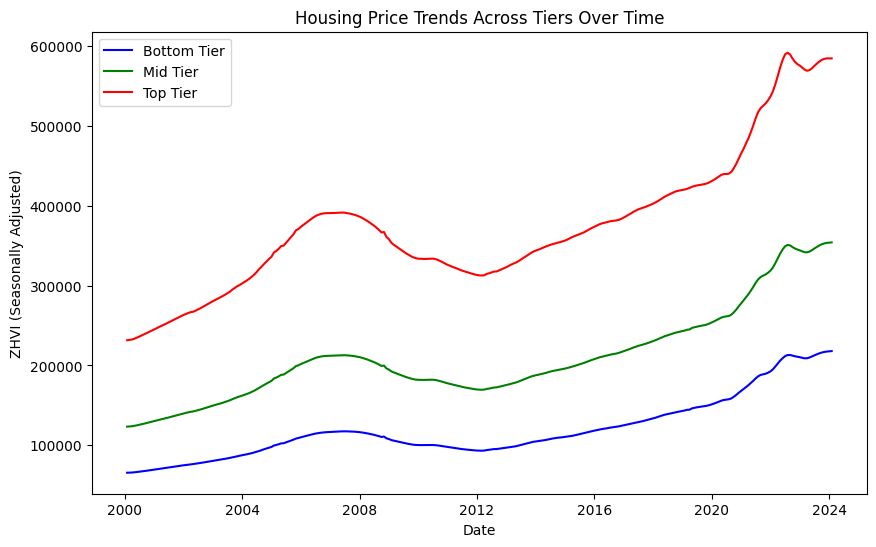

```python
# Group by 'Date' to calculate mean ZHVI values over time
zhvi_by_date = home_values.groupby('Date')[['Bottom Tier ZHVI (Smoothed) (Seasonally Adjusted)',
                                            'Mid Tier ZHVI (Smoothed) (Seasonally Adjusted)',
                                            'Top Tier ZHVI (Smoothed) (Seasonally Adjusted)']].mean().reset_index()

# Visualize trends over time
plt.figure(figsize=(10,6))
plt.plot(zhvi_by_date['Date'], zhvi_by_date['Bottom Tier ZHVI (Smoothed) (Seasonally Adjusted)'], label='Bottom Tier', color='blue')
plt.plot(zhvi_by_date['Date'], zhvi_by_date['Mid Tier ZHVI (Smoothed) (Seasonally Adjusted)'], label='Mid Tier', color='green')
plt.plot(zhvi_by_date['Date'], zhvi_by_date['Top Tier ZHVI (Smoothed) (Seasonally Adjusted)'], label='Top Tier', color='red')
plt.xlabel('Date')
plt.ylabel('ZHVI (Seasonally Adjusted)')
plt.title('Housing Price Trends Across Tiers Over Time')
plt.legend()
plt.show()
```

**General Observations:**

- Overall Upward Trend: Economic growth and inflation likely contributed to the general increase in housing prices over time.
- Market Volatility: More pronounced fluctuations in the top tier.
  - The top tier's fluctuations could be due to speculative investments and sensitivity to economic changes.
- Growth Rates:
  - Top Tier: Steeper increase, indicating higher appreciation.
    - High-net-worth individuals and investors can drive higher demand for luxury properties and limited supply might intensify competition and drive up prices.
  - Bottom Tier: Slower growth compared to the top tier.
    - Affordable housing, greater supply, but more price sensitive which may limit potential for rapid price increases.

**Historically speaking, we can see:**

- 2008 Financial Crisis: The dip reflects the housing bubble burst, leading to decreased demand and tighter lending practices.
  - *According to external research*: The housing market crash of 2008 remains one of the most significant events in the history of the United States housing market. It was caused by a combination of factors, including the subprime mortgage crisis, high levels of debt, and a lack of regulation in the financial sector.
- Post-2012 Recovery: All tiers recover, with the top tier rebounding more strongly.
  - Economic recovery and government interventions, i.e., low interest rates, market rebound support.
- Recent Surge (2020+): Sharp price increases likely due to low interest rates and high demand.
  - Pandemic-induced factors such as remote work increased demand for homes, coupled with historically low interest rates.

However, the graph above ignores the individuality among the different states, so now let's focus on how housing prices differ between states.

### Question to answer: Housing prices in different states?

**Goal**: Examine the variation in housing prices across different states.

**Approach**:

- Use box plots to visualize the distribution of ZHVI values across different states.
- Group data by State and examine the distribution of ZHVI values across states.

**Scope**: Past 5 years (2019-2023)

Reasons for box plot:

- Visualize distribution of data, including the median, quartiles, and potential outliers
- Highlighted variations and outliers; reveal skewness and symmetry
- Effectively summarize and visualize large datasets

```python
#Extract only data of past 5 years
filtered_data = home_values[
    (home_values['Date'] >= pd.Timestamp('2019-01-01')) &
    (home_values['Date'] < pd.Timestamp('2024-01-01'))
]
```

### Group by State & Tier

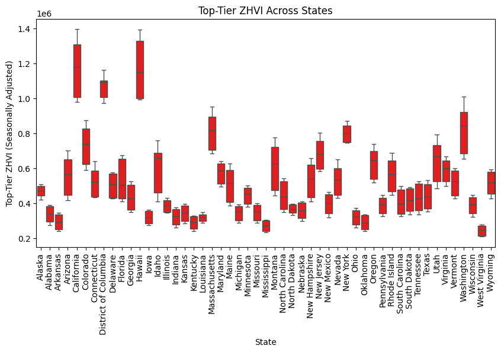

```python
# Top-Tier

plt.figure(figsize=(10, 5))
sns.boxplot(x='State', y='Top Tier ZHVI (Smoothed) (Seasonally Adjusted)', data=filtered_data, color = 'red')
plt.xticks(rotation=90)
plt.title('Top-Tier ZHVI Across States')
plt.xlabel('State')
plt.ylabel('Top-Tier ZHVI (Seasonally Adjusted)')
plt.show()
```

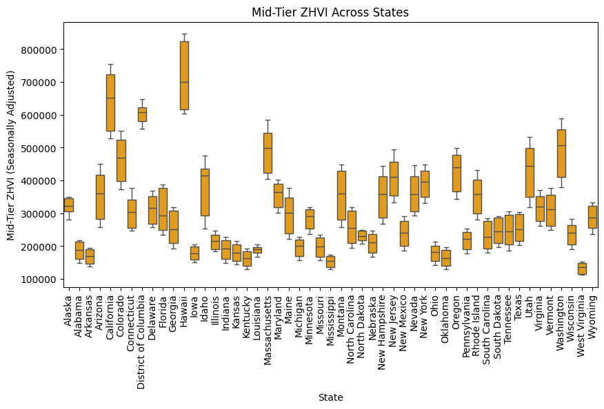

```python
# Mid-Tier

plt.figure(figsize=(10, 5))
sns.boxplot(x='State', y='Mid Tier ZHVI (Smoothed) (Seasonally Adjusted)', data=filtered_data, color = 'orange')
plt.xticks(rotation=90)
plt.title('Mid-Tier ZHVI Across States')
plt.xlabel('State')
plt.ylabel('Mid-Tier ZHVI (Seasonally Adjusted)')
plt.show()
```

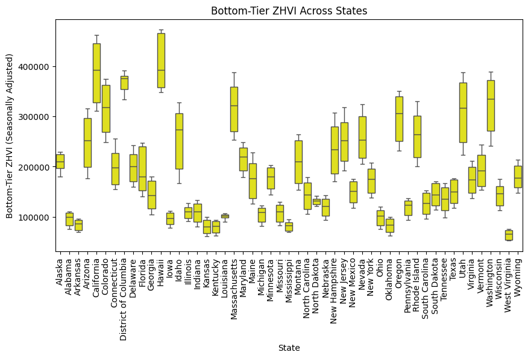

```python
# Bottom-Tier

plt.figure(figsize=(10, 5))
sns.boxplot(x='State', y='Bottom Tier ZHVI (Smoothed) (Seasonally Adjusted)', data=filtered_data, color = 'yellow')
plt.xticks(rotation=90)
plt.title('Bottom-Tier ZHVI Across States')
plt.xlabel('State')
plt.ylabel('Bottom-Tier ZHVI (Seasonally Adjusted)')
plt.show()
```

### Quick Observations of ZHVIs across Tiers

- High Variability:
  - States like **California** and **Hawaii** show significant price variation and higher medians.
    - High demand and limited supply in desirable locations contribute to variability.
- Outliers:
  - Upper outliers
    - High-value properties related to affluent areas or cities.
    - Some other possible reasons include factors like school districts, amenities, or proximity to employment locations.
  - Lower outliers
    - Distressed sales, properties needing significant renovation, properties in less desirable locations.

**Compare and Contrast:**

- Price Levels: Overall, top-tier has the highest medians, followed by mid-tier, and then bottom-tier.
- Possible Demand Factors: Top-tier influenced by *luxury demand*, mid-tier by middle-class *affordability*, and bottom-tier by *economic accessibility*.
- Market Stability: Top-tier and bottom-tier shows more volatility, while mid-tier is more stable with predictable pricing.

### Decision-making & Recommendations

1. Housing for High-Income Buyers (Top-Tier ZHVI):
   - Look for properties in states like California, Hawaii, and New York as they have higher top-tier ZHVI values compared to others, which may appreciate over time.
2. Housing for Middle-Income Buyers (Mid-Tier ZHVI):
   - Families looking for affordable yet appreciating homes should explore states like Arizona or Montana as they allow for a wider range of house values that give people more choices.
3. Housing for Low-Income or Budget Buyers (Bottom-Tier ZHVI):
   - States like Mississippi, Kansas, and West Virginia have lower bottom-tier home values, making them more affordable for low-income buyers.

However, overall, buyers should consider specific regions within states to find the most appropriate housing options based on their budget and preferences. Investors, on the other hand, could explore properties across different tiers in states with wide spreads to maximize potential returns on investment. Examples states such as California suggest high investment potential for both high-end and mid-tier housing markets as there is a broader range of home values.

## Rentals

Now, let's switch to exploring the rentals dataset.

### Question to answer: How effectively can we use seasonally adjusted and smoothed rent data to forecast future rent prices based on Region and Date?

**Goal**: Forecast rent prices using seasonally adjusted and smoothed rent data based on features such as Region, Date, and historical rent values.

**Approach**:

- Use a Random Forest Regressor model to predict rent prices.
- Input features include Region, Date, and historical rent data.
- The Random Forest model is chosen for its ability to capture non-linear relationships between features and rent prices, without strong assumptions about seasonality.
- Perform hyperparameter tuning (e.g., n_estimators) using GridSearchCV to optimize model performance.
- Look at performance measures to evaluate the results

Random Forest is used since it can capture non-linear patterns and generalize well on unseen data without requiring strong assumptions about seasonality.

**Scope**: Past 5 years

```python
#Extract only data of past 5 years
filtered_rentals = rentals[
    (rentals['Date'] >= pd.Timestamp('2019-01-01')) &
    (rentals['Date'] < pd.Timestamp('2024-01-01'))
]
```

```python
filtered_rentals
```

|  | Region ID | Size Rank | Region | Region Type | State | Home Type | Date | Rent (Smoothed) | Rent (Smoothed) (Seasonally Adjusted) |
| --- | --- | --- | --- | --- | --- | --- | --- | --- | --- |
| 48 | 66 | 146 | Ada County | 2 | Ada County | 4 | 2019-01-31 | 1221.303345 | 1221.303345 |
| 49 | 66 | 146 | Ada County | 2 | Ada County | 4 | 2019-02-28 | 1225.927734 | 1225.927734 |
| 50 | 66 | 146 | Ada County | 2 | Ada County | 4 | 2019-03-31 | 1231.874268 | 1231.874268 |
| 51 | 66 | 146 | Ada County | 2 | Ada County | 4 | 2019-04-30 | 1241.468018 | 1241.468018 |
| 52 | 66 | 146 | Ada County | 2 | Ada County | 4 | 2019-05-31 | 1250.416870 | 1250.416870 |
| ... | ... | ... | ... | ... | ... | ... | ... | ... | ... |
| 1258735 | 857850 | 713 | Cherry Hill | 1 | Camden County | 4 | 2023-08-31 | 2291.604736 | 2244.960938 |
| 1258736 | 857850 | 713 | Cherry Hill | 1 | Camden County | 4 | 2023-09-30 | 2296.188965 | 2254.213135 |
| 1258737 | 857850 | 713 | Cherry Hill | 1 | Camden County | 4 | 2023-10-31 | 2292.270996 | 2261.540527 |
| 1258738 | 857850 | 713 | Cherry Hill | 1 | Camden County | 4 | 2023-11-30 | 2253.417236 | 2257.956055 |
| 1258739 | 857850 | 713 | Cherry Hill | 1 | Camden County | 4 | 2023-12-31 | 2280.830322 | 2280.830322 |

327294 rows × 9 columns

```python
# Prepare data for forecasting
filtered_rentals['Year'] = filtered_rentals['Date'].dt.year
```

```python
from sklearn.model_selection import train_test_split

X = filtered_rentals[['Region ID', 'Year']]
y = filtered_rentals['Rent (Smoothed) (Seasonally Adjusted)']

# Train/test split
X_train, X_test, y_train, y_test = train_test_split(X, y, test_size=0.3, random_state=42)
```

```python
from sklearn.model_selection import GridSearchCV
from sklearn.ensemble import RandomForestRegressor

params = {"n_estimators": [10, 50, 100, 200]}

rf = RandomForestRegressor(random_state=42)
# using scoring method of R^2 here
search = GridSearchCV(estimator=rf, param_grid=params, cv=5, scoring='r2', error_score='raise', n_jobs=-1)
search.fit(X_train, y_train)

print(f"Best performance (accuracy) using random forest is {search.best_score_} with an n_estimators of {search.best_params_['n_estimators']}")
```

```
Best performance (accuracy) using random forest is 0.9542338572480624 with an n_estimators of 100
```

### Performance measures

```python
best_model = search.best_estimator_ #here, random contains the instance of the random forest model that performed the best during cross-validation
y_pred = best_model.predict(X_test)
```

```python
from sklearn.metrics import mean_squared_error, r2_score, mean_absolute_error, root_mean_squared_error

# Calculate regression metrics
mse = mean_squared_error(y_test, y_pred)
rmse = root_mean_squared_error(y_test, y_pred) # Taking the square root for RMSE
r2 = r2_score(y_test, y_pred)
mae = mean_absolute_error(y_test, y_pred)

print(f"Mean Squared Error (MSE): {mse}")
print(f"Root Mean Squared Error (RMSE): {rmse}")
print(f"R-squared (R2): {r2}")
print(f"Mean Absolute Error (MAE): {mae}")
```

```
Mean Squared Error (MSE): 76169.04292924434
Root Mean Squared Error (RMSE): 275.9873963231733
R-squared (R2): 0.9543291050297065
Mean Absolute Error (MAE): 45.986223239683156
```

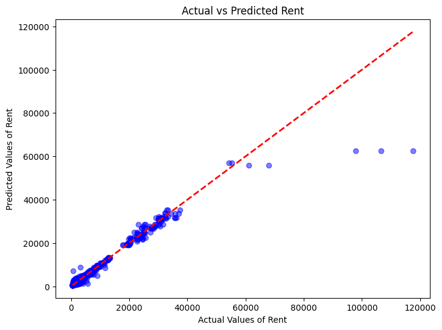

```python
# Scatter plot of actual vs predicted values
plt.figure(figsize=(8, 6))
plt.scatter(y_test, y_pred, alpha=0.5, color='blue')
plt.plot([y_test.min(), y_test.max()], [y_test.min(), y_test.max()], 'r--', lw=2)
plt.xlabel('Actual Values of Rent')
plt.ylabel('Predicted Values of Rent')
plt.title('Actual vs Predicted Rent')
plt.show()
```

### Observations & Discussion

1. The Random Forest Regressor achieved a strong performance with an R² score of ~0.95 using 100 estimators.
   - This means that the model explains 95.42% of the variance in the rent values.
   - R² is used as it provides a simple and intuitive measure for regression tasks of how much variance in the dependent variable (rent) is explained by the model -- to better understand the overall accuracy and predictive power of the model.
2. The red dashed line in the graph above represents the ideal scenario where the actual and predicted values are equal (i.e., x = y).
3. We can see that most of the points are clustered closely around the red line, indicating that the model is performing well for most predictions, as the predicted values are similar to the actual rent values.
4. Despite this strong performance indicated by the R² score, the scatter plot shows that the model struggles with predicting higher rent values, where significant under-predictions occur. Possible reasons might include:
   - The rent values might have a skewed distribution, with most properties falling into lower and mid-range values.
   - Also, we used "Rent (Smoothed) (Seasonally Adjusted)" which filtered out seasonal noise and extreme values. So, it may reduce the model’s ability to capture extreme or non-typical rent values, contributing to the underpredictions seen for high-end properties.

### Possible Future Steps to Improve

- Feature Engineering:
  - We can further explore additional features or interactions that may better capture the characteristics of higher-value rentals.
- Model Tuning:
  - We can also djust the hyperparameters of the Random Forest model, such as increasing the number of estimators or modifying the depth of trees, to potentially improve predictions for outliers.